# difference-in-difference plots

### difference-in-difference plots regarding a new bike lane

Below are a few exploratory difference-in-difference line plots generated from a survey which questioned pedestrians about their travel and shopping behaviour before and after the implementation of a bike lane in central Toronto (Bloor Street). Plots were built using ggplot2 and Rmarkdown sometime during the summer of 2017 as part of preliminary descriptive analysis for a report on the economic impacts of the bike lane.

**[Click here for a detailed research report regarding this project](https://tspace.library.utoronto.ca/bitstream/1807/82542/1/Bloor-Economic-Impact-Study-Full-Report-10-11-2017%20%282%29.pdf)**

The plots were generated using ggplot2 and Rmarkdown. The p-value pertains to a statistical test that compares whether the changes in percents are significantly different between the two sites - **[*Jeff Allen*](http://jamaps.github.io/)**

### Survey Summary

n table

|  | Bloor (case) | Danforth (control) | Total |
| --- | --- | --- | --- |
| pre bike lane | 842 | 173 | 1015 |
| post bike lane | 1577 | 412 | 1989 |
| total | 2419 | 585 | 3004 |

### Mode Share of Visitors

= Bloor = Danforth

percent of visitors who arrive by **bike** percent of visitors who arrive by **car**

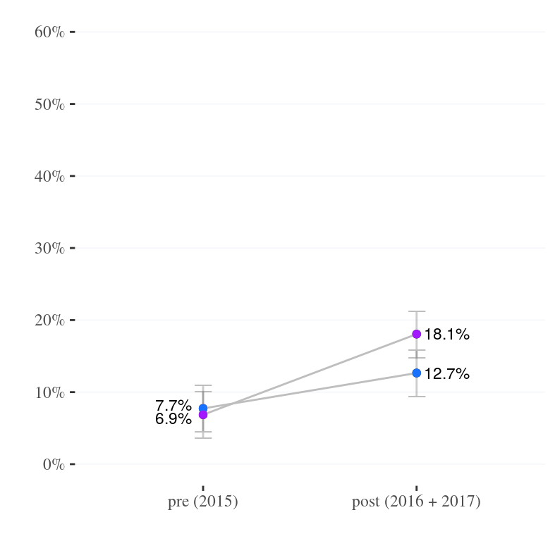

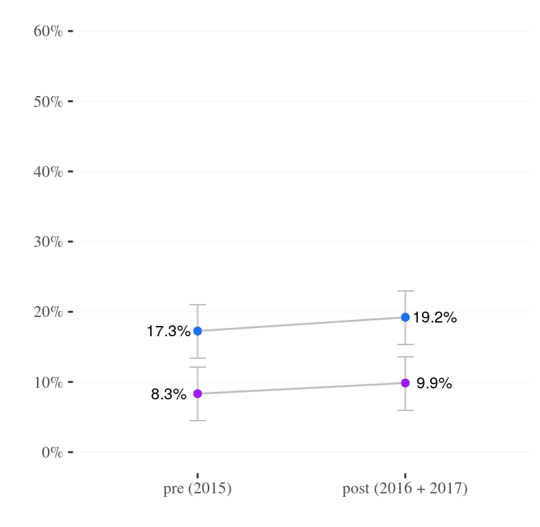

DiD p = 0.073 DiD p = 0.402

percent of visitors who arrive by **transit** percent of visitors who arrive by **walk**ing

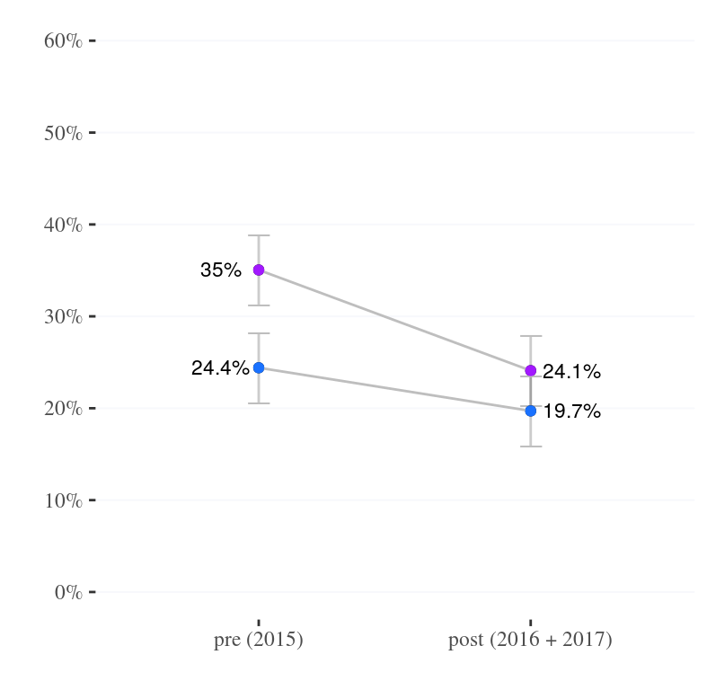

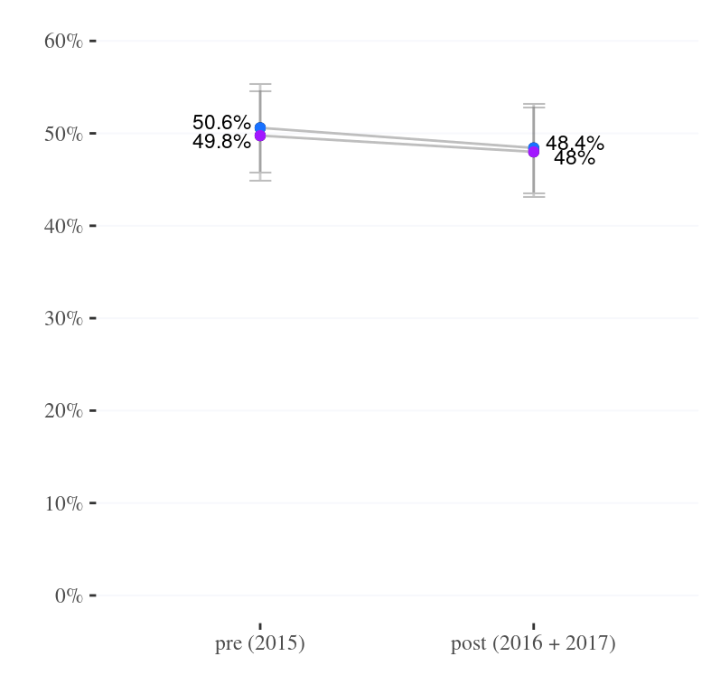

DiD p = 0.186 DiD p = 0.469

### Cycling Frequency

= Bloor = Danforth

percent of visitors who cycle to the street at least one day per week

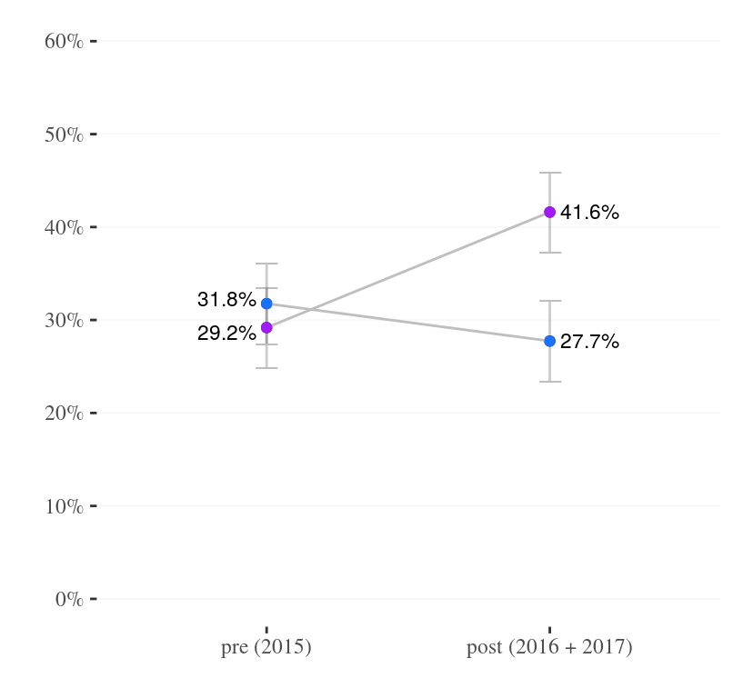

DiD p = 0.001

### Cycling Safety

= Bloor = Danforth

percent of visitors who **feel safe** biking on the street

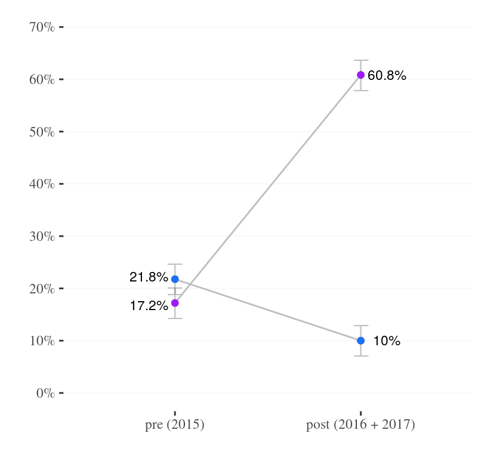

DiD p = 0.000

### Visit Frequency

= Bloor = Danforth

Percent who visit 15 or more days per month

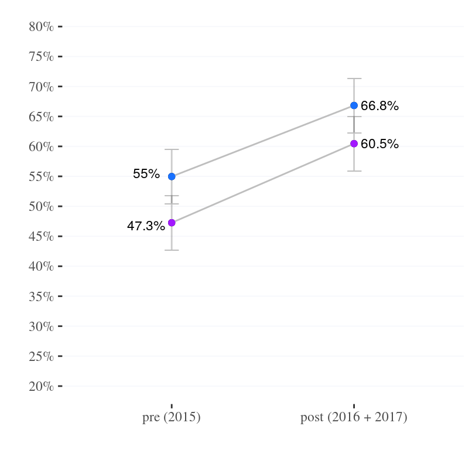

DiD p = 0.335

### Monthly Spending:

= Bloor = Danforth

percent of **all** visitors who spend more than $100 per month

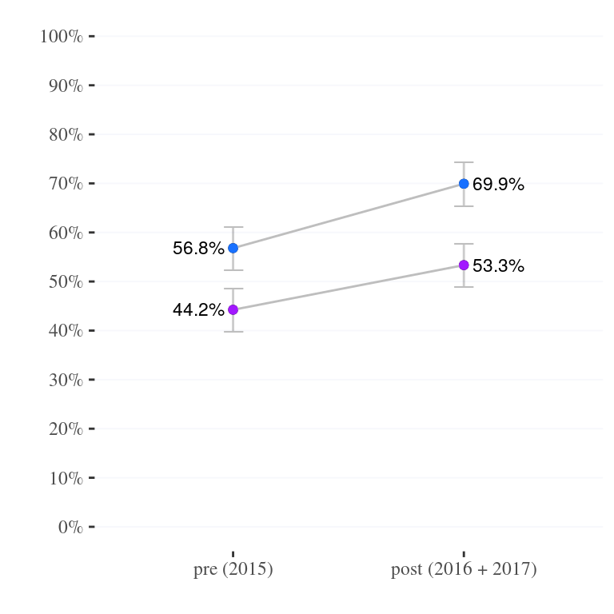

DiD p = 0.399

#### Subseting by mode:

percent of **cyclists** who spend more than $100 per month: percent of **drivers** who spend more than $100 per month:

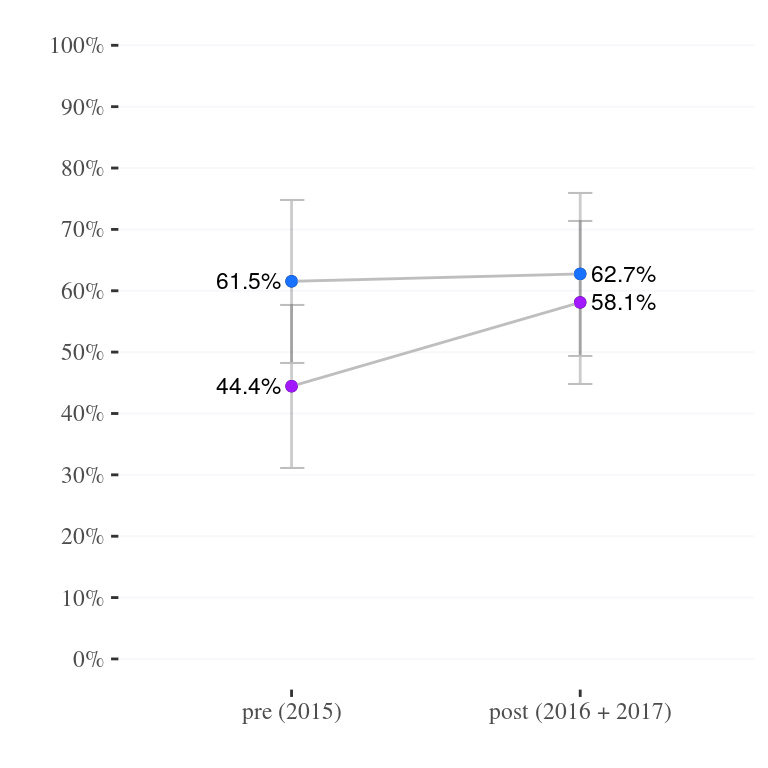

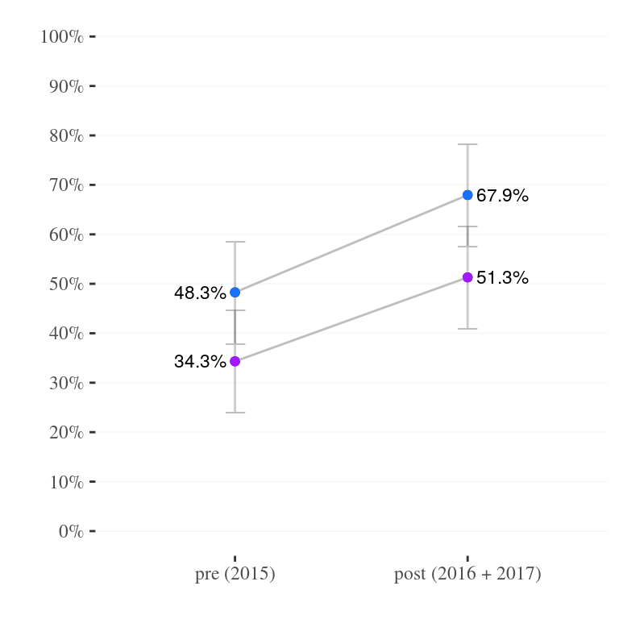

DiD p = 0.198 DiD p = 0.415

percent of **transit** riders who spend more than $100 per month: percent of **walkers** who spend more than $100 per month:

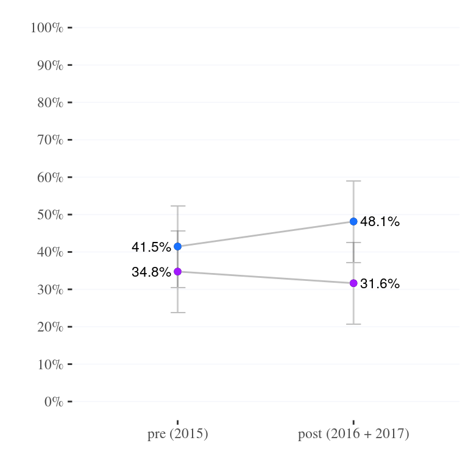

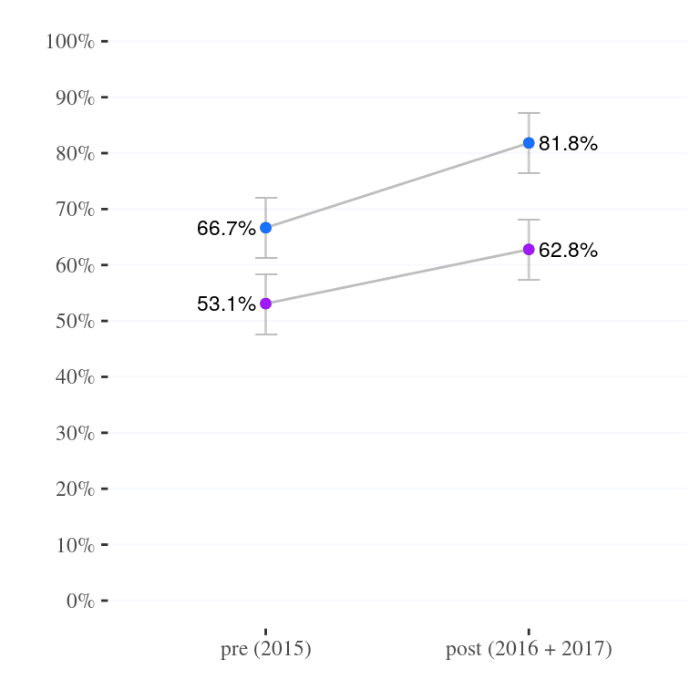

DiD p = 0.161 DiD p = 0.354